# A Priori

Erick Marroquín

# 1. Contexto y objetivo

En este análisis se utiliza el algoritmo Apriori para explorar patrones frecuentes y reglas de asociación en datos transaccionales.

La secuencia del análisis sigue los pasos conceptuales vistos en clase:

1. Identificar los grupos que más se repiten
2. Calcular el soporte de esos grupos
3. Generar reglas de asociación a partir de ellos
4. Calcular soporte, confianza y lift
5. Analizar los resultados gráficamente

# 2. Carga de librerías y datos

```r
library(arules)
library(arulesViz)
```

Información sobre los datos

```r
data(Groceries)
Groceries
```

```
## transactions in sparse format with
##  9835 transactions (rows) and
##  169 items (columns)
```

```r
summary(Groceries)
```

```
## transactions as itemMatrix in sparse format with
##  9835 rows (elements/itemsets/transactions) and
##  169 columns (items) and a density of 0.02609146
##
## most frequent items:
##       whole milk other vegetables       rolls/buns             soda
##             2513             1903             1809             1715
##           yogurt          (Other)
##             1372            34055
##
## element (itemset/transaction) length distribution:
## sizes
##    1    2    3    4    5    6    7    8    9   10   11   12   13   14   15   16
## 2159 1643 1299 1005  855  645  545  438  350  246  182  117   78   77   55   46
##   17   18   19   20   21   22   23   24   26   27   28   29   32
##   29   14   14    9   11    4    6    1    1    1    1    3    1
##
##    Min. 1st Qu.  Median    Mean 3rd Qu.    Max.
##   1.000   2.000   3.000   4.409   6.000  32.000
##
## includes extended item information - examples:
##        labels  level2           level1
## 1 frankfurter sausage meat and sausage
## 2     sausage sausage meat and sausage
## 3  liver loaf sausage meat and sausage
```

# 3. Ítems más frecuentes

Antes de analizar grupos de ítems, observamos qué productos aparecen con mayor frecuencia.

```r
itemFrequency(Groceries)[1:10]
```

```
##       frankfurter           sausage        liver loaf               ham
##       0.058973055       0.093950178       0.005083884       0.026029487
##              meat finished products   organic sausage           chicken
##       0.025826131       0.006507372       0.002236909       0.042907982
##            turkey              pork
##       0.008134215       0.057651246
```

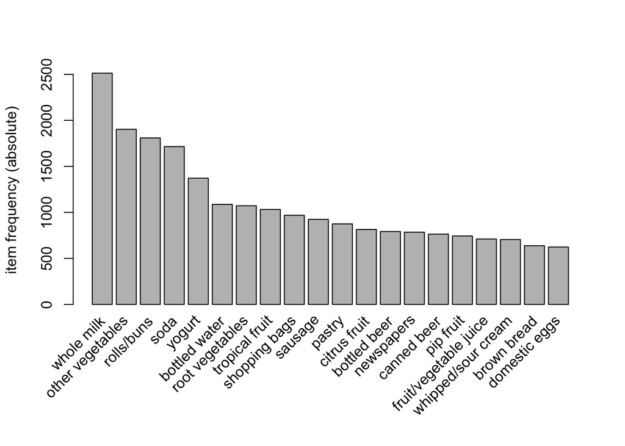

```r
itemFrequencyPlot(Groceries, topN = 20, type = "absolute")
```

# 4. Conjuntos de ítems frecuentes

Identificamos los **conjuntos de ítems que se repiten con mayor frecuencia** en las transacciones.

```r
itemsets_freq <- apriori(
  Groceries,
  parameter = list(
    target = "frequent itemsets",
    supp = 0.01,
    minlen = 2
  )
)
```

```
## Apriori
##
## Parameter specification:
##  confidence minval smax arem  aval originalSupport maxtime support minlen
##          NA    0.1    1 none FALSE            TRUE       5    0.01      2
##  maxlen            target  ext
##      10 frequent itemsets TRUE
##
## Algorithmic control:
##  filter tree heap memopt load sort verbose
##     0.1 TRUE TRUE  FALSE TRUE    2    TRUE
##
## Absolute minimum support count: 98
##
## set item appearances ...[0 item(s)] done [0.00s].
## set transactions ...[169 item(s), 9835 transaction(s)] done [0.00s].
## sorting and recoding items ... [88 item(s)] done [0.00s].
## creating transaction tree ... done [0.00s].
## checking subsets of size 1 2 3 4 done [0.00s].
## sorting transactions ... done [0.00s].
## writing ... [245 set(s)] done [0.00s].
## creating S4 object  ... done [0.00s].
```

```r
itemsets_freq
```

```
## set of 245 itemsets
```

```r
inspect(head(sort(itemsets_freq, by = "support"), 10))
```

```
##      items                               support    count
## [1]  {other vegetables, whole milk}      0.07483477 736
## [2]  {whole milk, rolls/buns}            0.05663447 557
## [3]  {whole milk, yogurt}                0.05602440 551
## [4]  {root vegetables, whole milk}       0.04890696 481
## [5]  {root vegetables, other vegetables} 0.04738180 466
## [6]  {other vegetables, yogurt}          0.04341637 427
## [7]  {other vegetables, rolls/buns}      0.04260295 419
## [8]  {tropical fruit, whole milk}        0.04229792 416
## [9]  {whole milk, soda}                  0.04006101 394
## [10] {rolls/buns, soda}                  0.03833249 377
```

# 5. Análisis del soporte de los conjuntos

```r
itemsets_df <- as(itemsets_freq, "data.frame")
head(itemsets_df)
```

```
##                            items    support count
## 1       {whole milk,hard cheese} 0.01006609    99
## 2 {other vegetables,butter milk} 0.01037112   102
## 3       {whole milk,butter milk} 0.01159126   114
## 4               {ham,whole milk} 0.01148958   113
## 5     {whole milk,sliced cheese} 0.01077783   106
## 6               {whole milk,oil} 0.01128622   111
```

```r
summary(itemsets_df$support)
```

```
##    Min. 1st Qu.  Median    Mean 3rd Qu.    Max.
## 0.01007 0.01149 0.01423 0.01745 0.02044 0.07483
```

El soporte indica la proporción de transacciones que contienen un conjunto específico de ítems.

# 6. Generación de reglas de asociación

A partir de los conjuntos frecuentes, se generan reglas del tipo **Antecedente → Consecuente**.

```r
rules <- apriori(
  Groceries,
  parameter = list(
    supp = 0.01,
    conf = 0.3
  )
)
```

```
## Apriori
##
## Parameter specification:
##  confidence minval smax arem  aval originalSupport maxtime support minlen
##         0.3    0.1    1 none FALSE            TRUE       5    0.01      1
##  maxlen target  ext
##      10  rules TRUE
##
## Algorithmic control:
##  filter tree heap memopt load sort verbose
##     0.1 TRUE TRUE  FALSE TRUE    2    TRUE
##
## Absolute minimum support count: 98
##
## set item appearances ...[0 item(s)] done [0.00s].
## set transactions ...[169 item(s), 9835 transaction(s)] done [0.00s].
## sorting and recoding items ... [88 item(s)] done [0.00s].
## creating transaction tree ... done [0.00s].
## checking subsets of size 1 2 3 4 done [0.00s].
## writing ... [125 rule(s)] done [0.00s].
## creating S4 object  ... done [0.00s].
```

```r
rules
```

```
## set of 125 rules
```

# 7. Soporte, confianza y lift

```r
summary(rules)
```

```
## set of 125 rules
##
## rule length distribution (lhs + rhs):sizes
##  2  3
## 69 56
##
##    Min. 1st Qu.  Median    Mean 3rd Qu.    Max.
##   2.000   2.000   2.000   2.448   3.000   3.000
##
## summary of quality measures:
##     support          confidence        coverage            lift
##  Min.   :0.01007   Min.   :0.3079   Min.   :0.01729   Min.   :1.205
##  1st Qu.:0.01149   1st Qu.:0.3454   1st Qu.:0.02888   1st Qu.:1.608
##  Median :0.01454   Median :0.3978   Median :0.03711   Median :1.789
##  Mean   :0.01859   Mean   :0.4058   Mean   :0.04783   Mean   :1.906
##  3rd Qu.:0.02217   3rd Qu.:0.4496   3rd Qu.:0.05663   3rd Qu.:2.155
##  Max.   :0.07483   Max.   :0.5862   Max.   :0.19349   Max.   :3.295
##      count
##  Min.   : 99.0
##  1st Qu.:113.0
##  Median :143.0
##  Mean   :182.8
##  3rd Qu.:218.0
##  Max.   :736.0
##
## mining info:
##       data ntransactions support confidence
##  Groceries          9835    0.01        0.3
##                                                                  call
##  apriori(data = Groceries, parameter = list(supp = 0.01, conf = 0.3))
```

```r
inspect(head(sort(rules, by = "lift"), 10))
```

```
##      lhs                                   rhs                support
## [1]  {citrus fruit, other vegetables}   => {root vegetables}  0.01037112
## [2]  {tropical fruit, other vegetables} => {root vegetables}  0.01230300
## [3]  {beef}                             => {root vegetables}  0.01738688
## [4]  {citrus fruit, root vegetables}    => {other vegetables} 0.01037112
## [5]  {tropical fruit, root vegetables}  => {other vegetables} 0.01230300
## [6]  {other vegetables, whole milk}     => {root vegetables}  0.02318251
## [7]  {whole milk, curd}                 => {yogurt}           0.01006609
## [8]  {root vegetables, rolls/buns}      => {other vegetables} 0.01220132
## [9]  {root vegetables, yogurt}          => {other vegetables} 0.01291307
## [10] {tropical fruit, whole milk}       => {yogurt}           0.01514997
##      confidence coverage   lift     count
## [1]  0.3591549  0.02887646 3.295045 102
## [2]  0.3427762  0.03589222 3.144780 121
## [3]  0.3313953  0.05246568 3.040367 171
## [4]  0.5862069  0.01769192 3.029608 102
## [5]  0.5845411  0.02104728 3.020999 121
## [6]  0.3097826  0.07483477 2.842082 228
## [7]  0.3852140  0.02613116 2.761356  99
## [8]  0.5020921  0.02430097 2.594890 120
## [9]  0.5000000  0.02582613 2.584078 127
## [10] 0.3581731  0.04229792 2.567516 149
```

- **Soporte**: frecuencia de la regla
- **Confianza**: probabilidad del consecuente dado el antecedente
- **Lift**: fuerza real de la asociación

# 8. Filtrado de reglas relevantes

```r
rules_filtered <- subset(
  rules,
  subset = lift > 1.5 & confidence > 0.5
)
```

```r
inspect(rules_filtered)
```

```
##      lhs                                       rhs                support
## [1]  {curd, yogurt}                         => {whole milk}       0.01006609
## [2]  {other vegetables, butter}             => {whole milk}       0.01148958
## [3]  {other vegetables, domestic eggs}      => {whole milk}       0.01230300
## [4]  {yogurt, whipped/sour cream}           => {whole milk}       0.01087951
## [5]  {other vegetables, whipped/sour cream} => {whole milk}       0.01464159
## [6]  {pip fruit, other vegetables}          => {whole milk}       0.01352313
## [7]  {citrus fruit, root vegetables}        => {other vegetables} 0.01037112
## [8]  {tropical fruit, root vegetables}      => {other vegetables} 0.01230300
## [9]  {tropical fruit, root vegetables}      => {whole milk}       0.01199797
## [10] {tropical fruit, yogurt}               => {whole milk}       0.01514997
## [11] {root vegetables, yogurt}              => {whole milk}       0.01453991
## [12] {root vegetables, rolls/buns}          => {other vegetables} 0.01220132
## [13] {root vegetables, rolls/buns}          => {whole milk}       0.01270971
## [14] {other vegetables, yogurt}             => {whole milk}       0.02226741
##      confidence coverage   lift     count
## [1]  0.5823529  0.01728521 2.279125  99
## [2]  0.5736041  0.02003050 2.244885 113
## [3]  0.5525114  0.02226741 2.162336 121
## [4]  0.5245098  0.02074225 2.052747 107
## [5]  0.5070423  0.02887646 1.984385 144
## [6]  0.5175097  0.02613116 2.025351 133
## [7]  0.5862069  0.01769192 3.029608 102
## [8]  0.5845411  0.02104728 3.020999 121
## [9]  0.5700483  0.02104728 2.230969 118
## [10] 0.5173611  0.02928317 2.024770 149
## [11] 0.5629921  0.02582613 2.203354 143
## [12] 0.5020921  0.02430097 2.594890 120
## [13] 0.5230126  0.02430097 2.046888 125
## [14] 0.5128806  0.04341637 2.007235 219
```

# 9. Visualización de resultados

## 9.1 Soporte vs Confianza

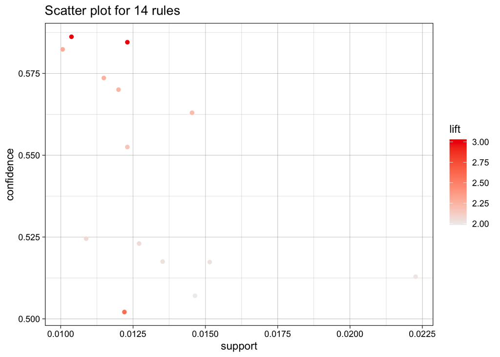

```r
plot(
  rules_filtered,
  method = "scatterplot",
  measure = c("support", "confidence"),
  shading = "lift"
)
```

## 9.2 Grafo de reglas de asociación

```r
plot(
  rules_filtered,
  method = "graph",
  engine = "htmlwidget"
)
```

[interactive chart not shown]

# 10. Conclusiones

- Los ítems frecuentes dominan los conjuntos frecuentes.
- El soporte permite descartar patrones poco representativos.
- No todas las reglas con alto soporte son interesantes.
- El lift ayuda a identificar asociaciones no triviales.
- Las visualizaciones facilitan la interpretación global.
- Apriori es una herramienta exploratoria para generar conocimiento descriptivo.